# Reproducible Research: Peer Assessment 1

## Loading and preprocessing the data

```r
library(lubridate)
library(dplyr)
```

```r
library(ggplot2)
library(stringr)
library(scales)

activity <- read.csv2("activity.csv", sep = ",") %>%
    mutate(date = ymd(date))
```

The data is in the variable “activity”

## What is mean total number of steps taken per day?

First we group activity by date and calculate the total number of steps for each group

Then we plot it with date on the x-axis, number of steps on the y-axis as a histogram of blue date columns with a descriptive title and labels and horizontal lines to identify the mean and median

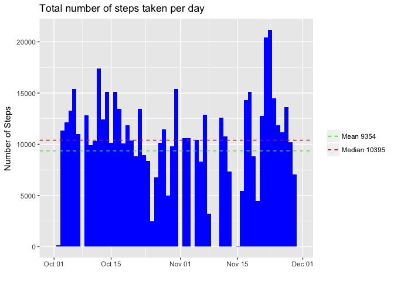

```r
activity.by.Date.Sum <- activity %>%
    group_by(date) %>%
    summarise(num.Steps = sum(steps, na.rm = T))

ggplot(activity.by.Date.Sum, aes(x=date, weight=num.Steps)) +
    geom_histogram(binwidth=1, fill="blue") +
    ylab("Number of Steps") +
    xlab("") +
    ggtitle("Total number of steps taken per day") +
    geom_hline(aes(yintercept=median(num.Steps, na.rm=T), linetype = paste("Median",median(num.Steps, na.rm=T))), colour = "red") +
    geom_hline(aes(yintercept=mean(num.Steps, na.rm=T), linetype = paste("Mean",format(round(mean(activity.by.Date.Sum$num.Steps, na.rm = TRUE), 0), nsmall = 0))), colour = "green") +
    scale_linetype_manual(name = "", values = c(2, 2),
                      guide = guide_legend(override.aes = list(color = c("green", "red"))))
```

## What is the average daily activity pattern?

First we group activity by interval and calculate the average number of steps for each group and convert the numeric interval to a time

We will need the time when the maximum number of steps were taken so we store it in time.Max.Avg.Steps

Then we plot it with time on the x-axis, number of steps on the y-axis as a line scale the x-axis to make the labels look nicer add a descriptive title and labels and a vertical line to identify the time.Max.Avg.Steps and print the time on the line

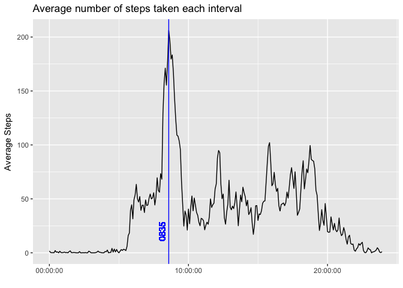

```r
activity.by.Interval.Average <- activity %>%
    group_by(interval) %>%
    summarise(avg.Steps = mean(steps, na.rm = T)) %>%
    mutate(interval = str_pad(interval, 4, pad = "0"),
           hour = substr(interval,1,2),
           minute = substr(interval,3,4),
           time = hms(paste0(hour,":",minute,":00")))

time.Max.Avg.Steps <- activity.by.Interval.Average[activity.by.Interval.Average$avg.Steps == max(activity.by.Interval.Average$avg.Steps),]$interval

ggplot(activity.by.Interval.Average, aes(time, avg.Steps)) +
    geom_line() +
    scale_x_time(labels = date_format("%H:%M", tz = "CET")) +
    xlab("") + ylab("Average Steps") +
    geom_vline(aes(xintercept = as.numeric(time.Max.Avg.Steps)*37), colour = "blue") +
    geom_text(aes(x=as.numeric(time.Max.Avg.Steps)*35, label=time.Max.Avg.Steps, y=20), angle=90, colour = "blue") +
    ggtitle("Average number of steps taken each interval")
```

## Imputing missing values

First calculate the number of rows with missing values and print it

Then create a function called impute.mean that replaces a null value with the mean

We then use this function on activity steps grouping by interval to impute for the mean of each interval

And then grouping by date to calculate the total number of steps per group

Then we plot it with date on the x-axis, number of steps on the y-axis as a histogram of blue date columns with a descriptive title and labels and horizontal lines to identify the mean and median

```r
print(paste("There are", as.character(sum(is.na(activity))), "rows with missing values"))
```

```
## [1] "There are 2304 rows with missing values"
```

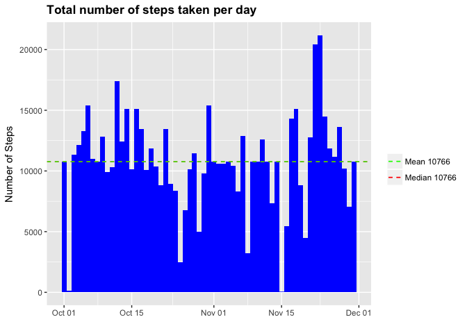

```r
impute.mean <- function(x) replace(x, is.na(x), mean(x, na.rm = TRUE))

#activity.no.missing <- ddply(activity, ~ interval, transform, steps = impute.mean(steps))

activity.no.missing <- activity %>%
    group_by(interval) %>%
    mutate(steps = impute.mean(steps))
#    do(impute.mean(.))

activity.no.missing.by.Date.Sum <- activity.no.missing %>%
    group_by(date) %>%
    summarize(num.Steps = sum(steps, na.rm = T))

ggplot(activity.no.missing.by.Date.Sum, aes(x=date, weight=num.Steps)) +
    geom_histogram(binwidth=1, fill="blue") +
    ylab("Number of Steps") +
    xlab("") +
    ggtitle("Total number of steps taken per day") +
    theme(plot.title = element_text(lineheight=.8, face="bold")) +
    geom_hline(aes(yintercept=median(num.Steps, na.rm=T), linetype = paste("Median",format(round(mean(activity.no.missing.by.Date.Sum$num.Steps, na.rm = TRUE), 0), nsmall = 0))), colour = "red") +
    geom_hline(aes(yintercept=mean(num.Steps, na.rm=T), linetype = paste("Mean",format(round(mean(activity.no.missing.by.Date.Sum$num.Steps, na.rm = TRUE), 0), nsmall = 0))), colour = "green") +
    scale_linetype_manual(name = "", values = c(2, 2),
                      guide = guide_legend(override.aes = list(color = c("green", "red"))))
```

After imputing missing values based on average steps for the interval, the mean and median values both increase.

## Are there differences in activity patterns between weekdays and weekends?

First we create a new variable that determines if the row is a weekend or weekday

then group by weekend/weekday and interval to calculate the average number of steps for each group

Then we plot it with time on the x-axis, number of steps on the y-axis as a line seperated by weekend and weekday and add a descriptive title and labels

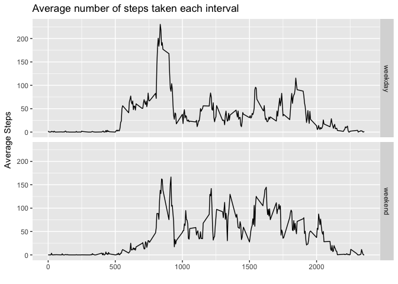

```r
activity.no.missing <- activity.no.missing %>%
    mutate(dayType = ifelse(wday(date) == 1 | wday(date) == 7, "weekend", "weekday"),
           intervalChr = str_pad(as.character(interval),4,pad = "0"))

activity.no.missing.by.Interval.Average <- activity.no.missing %>%
    group_by(dayType, interval) %>%
    summarize(steps = mean(steps))

ggplot(activity.no.missing.by.Interval.Average, aes(interval, steps)) +
    geom_line() +
    facet_grid(as.factor(dayType) ~ .) +
    xlab("") + ylab("Average Steps") +
    ggtitle("Average number of steps taken each interval")
```